# Pràctica 1

Grup 06

```r
library(tidyverse)
library(haven)
library(naniar)
library(compareGroups)
```

#### 1. Importació de les dades

```r
dades<-read_sas("uab_demo1.sas7bdat", catalog_file = "formats.sas7bcat")
dades <- dades %>%
  mutate(across(where(is.labelled), as_factor)) %>%
  mutate(across(
    where(is.factor),
    ~ case_when(
      str_detect(as.character(.), "No") ~ "No",
      str_detect(as.character(.), "Si") ~ "Si",
      TRUE ~ as.character(.))))%>%
  mutate(across(-c(1,3,PES, TALLA, IMC, NFractura), as.factor))%>%
  mutate(Grup =recode(Grup,"0"="control", "1"="tractament")) %>%
  mutate(Sexe=na_if(Sexe,"")) %>%
  mutate(across(where(is.factor), droplevels))

head(dades)
```

```
## # A tibble: 6 × 26
##   PatNo Grup    Edat Sexe  ServeiAlta   PES TALLA   IMC ALCOHOL Smoker Hipogonad
##   <dbl> <fct>  <dbl> <fct> <fct>      <dbl> <dbl> <dbl> <fct>   <fct>  <fct>
## 1     1 contr…    77 F     MDURG       75.3   162  29.5 0       0      No
## 2     2 contr…    77 F     MDURG       66.2   153  27.5 1       0      No
## 3     3 tract…    77 F     TRA         NA      NA  NA   0       0      No
## 4     4 tract…    NA F     TRA         NA      NA  NA   0       0      No
## 5     5 contr…    89 F     MDURG       NA      NA  NA   0       0      No
## 6     6 contr…    NA F     TOURG       59     158  23.6 0       0      No
## # ℹ 15 more variables: Artritis_reumatoide <fct>, Fractura <fct>,
## #   NFractura <dbl>, FX_familia <fct>, Diabetis <fct>, tipus_diabetis <fct>,
## #   Densitometries <fct>, Osteporosi <fct>, neoplasia <fct>,
## #   HiperTiroidisme <fct>, Malnutricio <fct>, Malabsorcio <fct>,
## #   Malaltia_Hep_Cro <fct>, OthRiskFract <fct>, CountActualGE4 <fct>
```

#### 2. Qualitat de les dades

```r
summary(dades)
```

```
##      PatNo               Grup          Edat         Sexe     ServeiAlta
##  Min.   :  1.0   control   :272   Min.   :51.00   F   :300   CGURG: 31
##  1st Qu.:102.8   tractament:136   1st Qu.:78.00   M   : 79   GOURG:  2
##  Median :204.5                    Median :84.00   NA's: 29   MDURG:225
##  Mean   :204.5                    Mean   :82.05              MED  :  2
##  3rd Qu.:306.2                    3rd Qu.:88.00              PSURG:  1
##  Max.   :408.0                    Max.   :95.00              TOURG: 13
##                                   NA's   :42                 TRA  :134
##       PES             TALLA            IMC        ALCOHOL Smoker  Hipogonad
##  Min.   : 38.50   Min.   :134.0   Min.   :17.90   0:379   0:362   No:408
##  1st Qu.: 57.10   1st Qu.:147.6   1st Qu.:25.41   1: 26   1: 15
##  Median : 67.50   Median :153.0   Median :28.09   2:  3   2: 31
##  Mean   : 67.39   Mean   :153.7   Mean   :28.82
##  3rd Qu.: 74.55   3rd Qu.:160.0   3rd Qu.:31.73
##  Max.   :107.00   Max.   :179.0   Max.   :55.00
##  NA's   :253      NA's   :286     NA's   :286
##  Artritis_reumatoide Fractura   NFractura      FX_familia Diabetis
##  No:404              No:296   Min.   :0.0000   No:408     No:281
##  Si:  4              Si:112   1st Qu.:0.0000              Si:127
##                               Median :0.0000
##                               Mean   :0.3382
##                               3rd Qu.:1.0000
##                               Max.   :7.0000
##
##  tipus_diabetis Densitometries Osteporosi neoplasia HiperTiroidisme Malnutricio
##  0:281          No:390         No:374     No:358    No:400          No:401
##  1:  2          Si: 18         Si: 34     Si: 50    Si:  8          Si:  7
##  2:125
##
##
##
##
##  Malabsorcio Malaltia_Hep_Cro OthRiskFract CountActualGE4
##  No:407      No:397           0:334        0: 94
##  Si:  1      Si: 11           1: 74        1:314
##
##
##
##
##
```

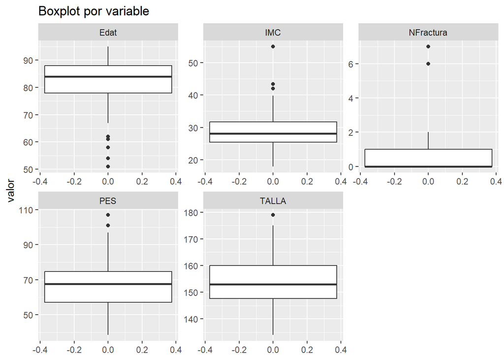

```r
dades %>%
  select(where(is.numeric)) %>%
  select(-PatNo) %>%
  pivot_longer(everything(), names_to = "variable", values_to = "valor")%>%
  ggplot(aes(y = valor)) +
  geom_boxplot() +
  facet_wrap(~ variable, scales = "free")+
  labs(title = "Boxplot por variable")
```

- **Edat**: La gran majoria de la població té una edat avançada, al voltant dels 84 anys, encara que podem veure com hi ha alguns casos puntuals de persones entre 50 i 65 anys.  
- **IMC**: La gran majoria té un IMC entre 25 i 32, indicant pes normal i sobrepés d’aquest. Destacan 3 casos amb valors força superiors, especialment un amb el doble de la mitjana.  
- **NFractura**: La majora o no s’ha fracturat o només ho fet 1 vegada. Resalten 2 casos que s’han fracturat 6 i 7 cops.  
- **Pes**: La majoria té un pes al voltant del 70 kg, encara que hi podem veure 2 casos amb un pes superior al 100 kg.  
- **Talla**: La majoria té una altura entre 148 i 160 cm, encara que resalta un cas amb una altura de 180 cm.  
Observem com en totes les variables, exceptuant l’edat, els valors extrems visualitzats es troben per sobre dels valors generals observats.

```r
dades %>%
  group_by(PatNo) %>%
  filter(n() > 1)
```

```
## # A tibble: 0 × 26
## # Groups:   PatNo [0]
## # ℹ 26 variables: PatNo <dbl>, Grup <fct>, Edat <dbl>, Sexe <fct>,
## #   ServeiAlta <fct>, PES <dbl>, TALLA <dbl>, IMC <dbl>, ALCOHOL <fct>,
## #   Smoker <fct>, Hipogonad <fct>, Artritis_reumatoide <fct>, Fractura <fct>,
## #   NFractura <dbl>, FX_familia <fct>, Diabetis <fct>, tipus_diabetis <fct>,
## #   Densitometries <fct>, Osteporosi <fct>, neoplasia <fct>,
## #   HiperTiroidisme <fct>, Malnutricio <fct>, Malabsorcio <fct>,
## #   Malaltia_Hep_Cro <fct>, OthRiskFract <fct>, CountActualGE4 <fct>
```

No hi ha subjectes duplicats

```r
dades %>%
  filter(round(PES/(TALLA/100)^2,1)!=round(IMC,1)) %>%
  nrow(.)/sum(!is.na(dades$IMC))
```

```
## [1] 0.1147541
```

Un 11.5% dels IMC estan mal calculats

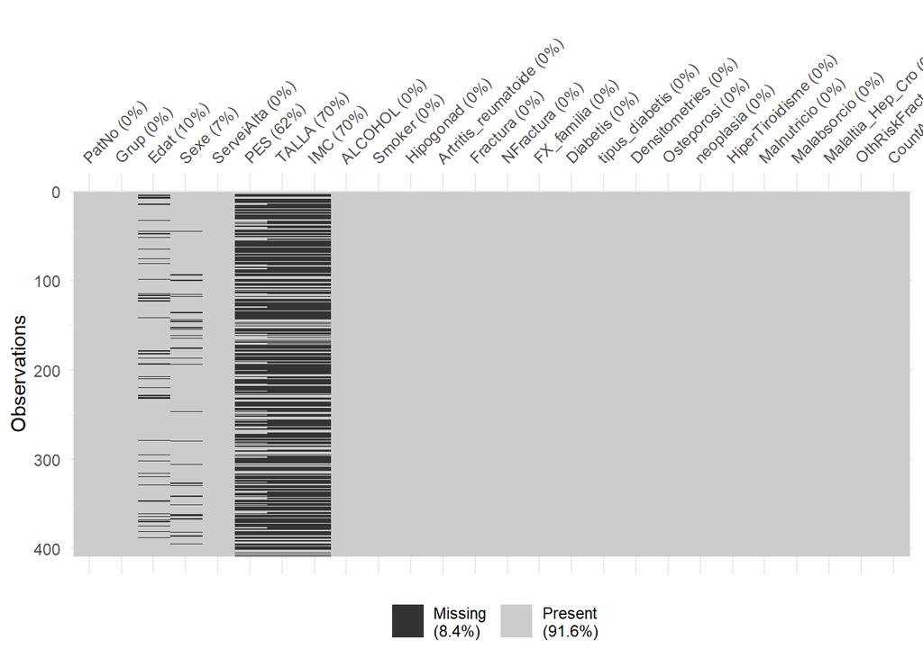

```r
vis_miss(dades)
```

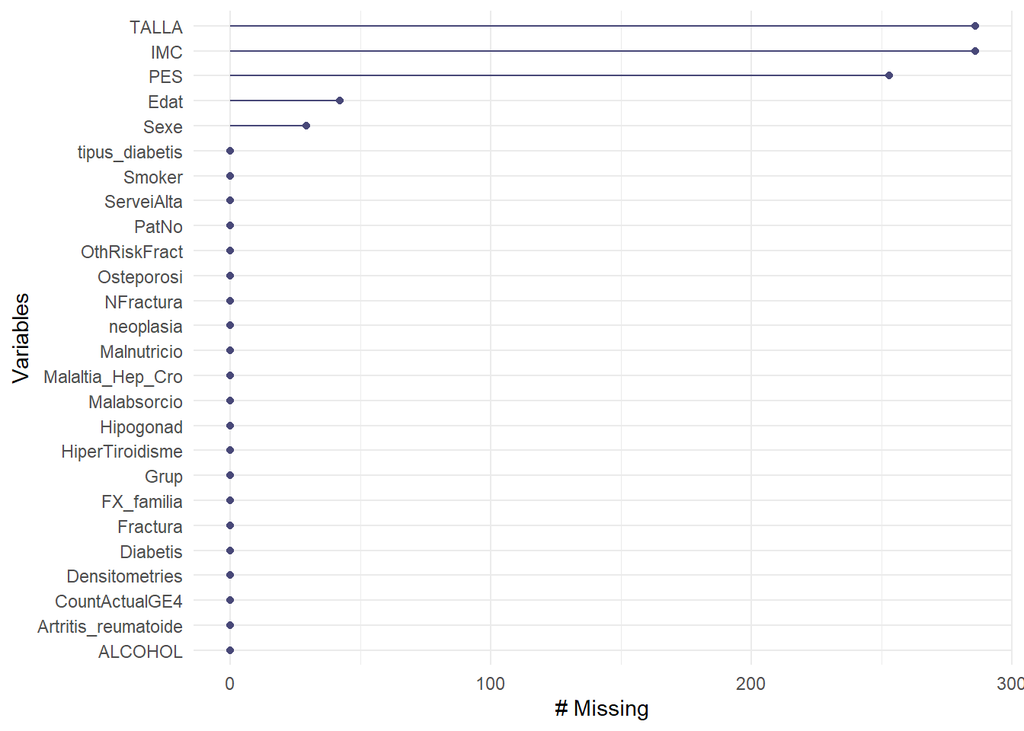

```r
gg_miss_var(dades)
```

```r
miss_var_summary(dades)
```

```
## # A tibble: 26 × 3
##    variable   n_miss pct_miss
##    <chr>       <int>    <num>
##  1 TALLA         286    70.1
##  2 IMC           286    70.1
##  3 PES           253    62.0
##  4 Edat           42    10.3
##  5 Sexe           29     7.11
##  6 PatNo           0     0
##  7 Grup            0     0
##  8 ServeiAlta      0     0
##  9 ALCOHOL         0     0
## 10 Smoker          0     0
## # ℹ 16 more rows
```

Veiem com les variables pes, talla i IMC tenen taxes de valors perduts molt grans (62%, 70% i 70% respectivament). Fixant-nos-hi una mica veiem com els que els hi falta IMC coincideixen bastant amb els missings de Talla i els que falten Pes faleten les altres dos variables, aixó s’ha dentendre junt a que son mesures molt realcionades (l’IMC surt de la relació de pes i altura) i que no es tenen aquestes caracteresitiques de gran part de la mostra.  
De la resta de variables només es veu que falta un 10% de les edats i un 7%, les demés estan totalement complertes.

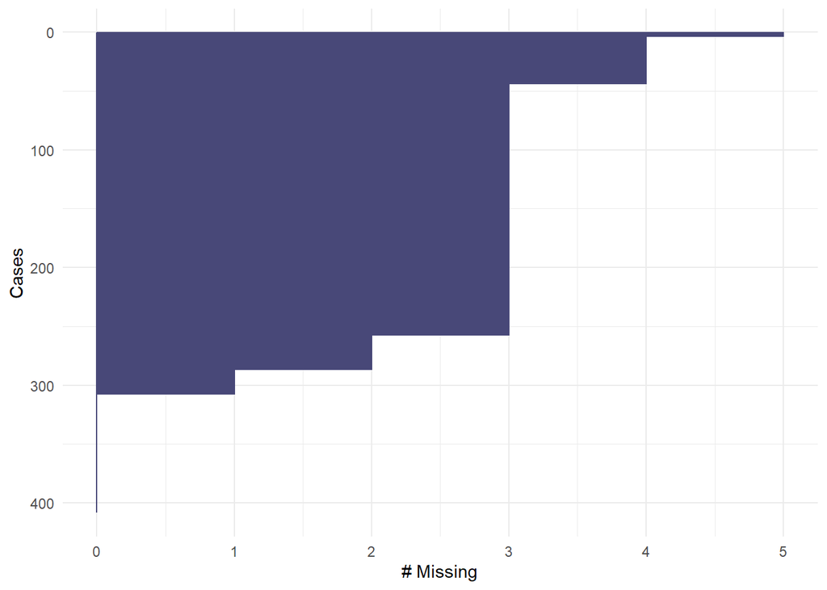

```r
gg_miss_case(dades)
```

```r
miss_case_table(dades)
```

```
## # A tibble: 6 × 3
##   n_miss_in_case n_cases pct_cases
##            <int>   <int>     <dbl>
## 1              0     101    24.8
## 2              1      21     5.15
## 3              2      29     7.11
## 4              3     214    52.5
## 5              4      40     9.80
## 6              5       3     0.735
```

Pel que fa a casos complerts veim com només ho son un 25% i el grup més nombros son els que tenen 3 varables faltants que representen un 52% dels casos.

```r
dades %>%
  filter(is.na(Edat))
```

```
## # A tibble: 42 × 26
##    PatNo Grup   Edat Sexe  ServeiAlta   PES TALLA   IMC ALCOHOL Smoker Hipogonad
##    <dbl> <fct> <dbl> <fct> <fct>      <dbl> <dbl> <dbl> <fct>   <fct>  <fct>
##  1     4 trac…    NA F     TRA         NA     NA   NA   0       0      No
##  2     6 cont…    NA F     TOURG       59    158   23.6 0       0      No
##  3     7 cont…    NA M     MDURG       71.2  167.  25.5 0       2      No
##  4    14 trac…    NA F     TRA         72.9   NA   NA   0       0      No
##  5    32 trac…    NA F     TRA         65    159   25.7 0       0      No
##  6    44 cont…    NA <NA>  MDURG       NA     NA   NA   0       0      No
##  7    47 cont…    NA F     MDURG       NA     NA   NA   0       0      No
##  8    51 trac…    NA F     TRA         67    152.  29   0       0      No
##  9    64 trac…    NA F     TRA         NA     NA   NA   0       0      No
## 10    75 trac…    NA M     TRA         NA     NA   NA   0       0      No
## # ℹ 32 more rows
## # ℹ 15 more variables: Artritis_reumatoide <fct>, Fractura <fct>,
## #   NFractura <dbl>, FX_familia <fct>, Diabetis <fct>, tipus_diabetis <fct>,
## #   Densitometries <fct>, Osteporosi <fct>, neoplasia <fct>,
## #   HiperTiroidisme <fct>, Malnutricio <fct>, Malabsorcio <fct>,
## #   Malaltia_Hep_Cro <fct>, OthRiskFract <fct>, CountActualGE4 <fct>
```

```r
dades %>%
  filter(is.na(Edat)) %>%
  miss_case_table()
```

```
## # A tibble: 4 × 3
##   n_miss_in_case n_cases pct_cases
##            <int>   <int>     <dbl>
## 1              1      12     28.6
## 2              3       2      4.76
## 3              4      25     59.5
## 4              5       3      7.14
```

Dels qui els hi falta la edat un 71% els hi falta alguna altra variable, i a la majoria els hi falten 3 més (pes, talla i IMC en gran porporció). Per tant, tenint en compte que sense la edat podem estar perdent una variable interessant per a futurs models i que a més a la majoria també els falten altres variables pot ser una bona estrategia elimitar aquests casos que només son un 10%.

```r
dades %>%
  filter(is.na(Sexe))
```

```
## # A tibble: 29 × 26
##    PatNo Grup   Edat Sexe  ServeiAlta   PES TALLA   IMC ALCOHOL Smoker Hipogonad
##    <dbl> <fct> <dbl> <fct> <fct>      <dbl> <dbl> <dbl> <fct>   <fct>  <fct>
##  1    44 cont…    NA <NA>  MDURG       NA     NA   NA   0       0      No
##  2    93 trac…    88 <NA>  TRA         NA     NA   NA   0       0      No
##  3    99 cont…    86 <NA>  MDURG       NA     NA   NA   0       2      No
##  4   115 cont…    75 <NA>  MDURG       42.7  143   20.9 0       0      No
##  5   117 cont…    75 <NA>  CGURG       NA     NA   NA   0       0      No
##  6   135 trac…    67 <NA>  TRA         NA     NA   NA   0       0      No
##  7   143 trac…    84 <NA>  TRA         70.4  143.  34.4 0       0      No
##  8   145 cont…    62 <NA>  MDURG       75    158   30.0 0       0      No
##  9   152 trac…    84 <NA>  TRA         57    147   26.4 0       0      No
## 10   154 trac…    76 <NA>  TRA         NA     NA   NA   0       0      No
## # ℹ 19 more rows
## # ℹ 15 more variables: Artritis_reumatoide <fct>, Fractura <fct>,
## #   NFractura <dbl>, FX_familia <fct>, Diabetis <fct>, tipus_diabetis <fct>,
## #   Densitometries <fct>, Osteporosi <fct>, neoplasia <fct>,
## #   HiperTiroidisme <fct>, Malnutricio <fct>, Malabsorcio <fct>,
## #   Malaltia_Hep_Cro <fct>, OthRiskFract <fct>, CountActualGE4 <fct>
```

```r
dades %>%
  filter(is.na(Sexe)) %>%
  miss_case_table()
```

```
## # A tibble: 4 × 3
##   n_miss_in_case n_cases pct_cases
##            <int>   <int>     <dbl>
## 1              1       9     31.0
## 2              3       2      6.90
## 3              4      15     51.7
## 4              5       3     10.3
```

```r
dades %>%
  filter(is.na(Edat) & is.na(Sexe)) %>%
  nrow(.)/sum(is.na(dades$Sexe))
```

```
## [1] 0.1034483
```

D’altra banda, amb la mateixa argumentació que per l’edat optaria per una solució similar. Sumant-li que un 10% dels missings de sexe també ho son d’edat.

#### 3. Comparació de les caracterísitiques dels dos grups

```r
compareGroups(Grup~., data=dades)%>%createTable()
```

```
##
## --------Summary descriptives table by 'Grup'---------
##
## ______________________________________________________
##                        control   tractament  p.overall
##                         N=272       N=136
## ¯¯¯¯¯¯¯¯¯¯¯¯¯¯¯¯¯¯¯¯¯¯¯¯¯¯¯¯¯¯¯¯¯¯¯¯¯¯¯¯¯¯¯¯¯¯¯¯¯¯¯¯¯¯
## PatNo                 205 (118)   204 (118)    0.989
## Edat                 82.1 (8.80) 82.0 (8.97)   0.931
## Sexe:                                          1.000
##     F                200 (79.1%) 100 (79.4%)
##     M                53 (20.9%)  26 (20.6%)
## ServeiAlta:                                   <0.001
##     CGURG            31 (11.4%)   0 (0.00%)
##     GOURG             2 (0.74%)   0 (0.00%)
##     MDURG            225 (82.7%)  0 (0.00%)
##     MED               0 (0.00%)   2 (1.47%)
##     PSURG             1 (0.37%)   0 (0.00%)
##     TOURG            13 (4.78%)   0 (0.00%)
##     TRA               0 (0.00%)  134 (98.5%)
## PES                  68.5 (13.7) 65.0 (11.6)   0.098
## TALLA                154 (8.70)  152 (7.83)    0.262
## IMC                  29.3 (5.84) 27.5 (4.90)   0.091
## ALCOHOL:                                       0.197
##     0                251 (92.3%) 128 (94.1%)
##     1                20 (7.35%)   6 (4.41%)
##     2                 1 (0.37%)   2 (1.47%)
## Smoker:                                        0.756
##     0                241 (88.6%) 121 (89.0%)
##     1                 9 (3.31%)   6 (4.41%)
##     2                22 (8.09%)   9 (6.62%)
## Hipogonad: No        272 (100%)  136 (100%)      .
## Artritis_reumatoide:                           1.000
##     No               269 (98.9%) 135 (99.3%)
##     Si                3 (1.10%)   1 (0.74%)
## Fractura:                                     <0.001
##     No               218 (80.1%) 78 (57.4%)
##     Si               54 (19.9%)  58 (42.6%)
## NFractura            0.25 (0.64) 0.51 (0.75)   0.001
## FX_familia: No       272 (100%)  136 (100%)      .
```

[output cut: 20 more lines]

```
##     No               268 (98.5%) 133 (97.8%)
##     Si                4 (1.47%)   3 (2.21%)
## Malabsorcio:                                   1.000
##     No               271 (99.6%) 136 (100%)
##     Si                1 (0.37%)   0 (0.00%)
## Malaltia_Hep_Cro:                              0.517
##     No               266 (97.8%) 131 (96.3%)
##     Si                6 (2.21%)   5 (3.68%)
## OthRiskFract:                                  0.751
##     0                221 (81.2%) 113 (83.1%)
##     1                51 (18.8%)  23 (16.9%)
## CountActualGE4:                                0.967
##     0                62 (22.8%)  32 (23.5%)
##     1                210 (77.2%) 104 (76.5%)
## ¯¯¯¯¯¯¯¯¯¯¯¯¯¯¯¯¯¯¯¯¯¯¯¯¯¯¯¯¯¯¯¯¯¯¯¯¯¯¯¯¯¯¯¯¯¯¯¯¯¯¯¯¯¯
```

Observem com en la majoria de variables no s’observen diferències significatives entre els dos grups evaluats. D’altre banda les variables on si s’observa això són:  
- **ServeiAlta**: amb un p-valor inferior a 0.01, on tots els pacients del grup Tractament, el 98.5%, van ser donats d’alta en TRA, mentre que els Control s’han distribuit en diferents grups, per tant, s’observa com hi ha una clara diferència en la distribució entre grups.  
- **Fractura**: en el grup Control només el 19.9% tenien fractura prèvia, mentre que els Tractament un 42.6%.  
- **NFractura**: la mitjana del número de fractures del grup Control es de 0.25 +- 0.64 i dels Tractament 0.51 +-0.75, observant diferències signficatives entre ambdós.  
- **Osteoporosis**: en el cas dels Controls el 94.5% dels pacient no tenen osteoporosis a diferència del 86.0% dels Tractaments.  
Per tant, el grup Tractament mostra un pacients amb més fractures prèvies, més fractura en total i una major proporció d’osteoporosis.

#### 4. Possible diseny de l’estudi

En aquest estudi s’estan comparant dos grups ja existents: Control i Tractament. Aquests no s’han assignat de forma aleatòria a cada grup, sinó que pertanyen a cada categoria segons la fragilitat òssia. Això suggereix que l’estudi podria ser retrospectiu, on s’analitzen dades ja recollides de casos i controls per tractar d’identificar els factors de risc associats a les fractures on els casos són els pacients amb fractures prèvies per fragilitat òssia i els control no.